# EDA cema internship task

Casey Otieno

2023-07-21

The dataset provided contains monthly data for children <5 years, disaggregated at a county level for the period January 2021 to June 2023.

The dataset contains the following varibales:

- Period (months from January 2021 to June 2023)
- County (the 47 counties in Kenya)
- Total number of children dewormed (Total Dewormed)
- Number of children <5 years with acute malnutrition (Acute Malnutrition)
- Number of children stunted (0-6 months, 6-23 months, 24-59 months)
- Number of children <5 years with diarrhe (Diarrhea cases)
- Number of children who are underweight (0-6 months, 6-23 months, 24-59 months)

#Install pre-requisite packages

```r
#install.packages("readr")
library("readr")
```

# Load and explore dataset

Load the first five rows of the dataset and summarize it.

```r
cema_internship_task_2023=read_csv('https://raw.githubusercontent.com/cema-uonbi/internship_task/main/data/cema_internship_task_2023.csv')
head(cema_internship_task_2023,5)
```

```
## # A tibble: 5 x 11
##   period county      `Total Dewormed` `Acute Malnutrition` `stunted 6-23 months`
##   <chr>  <chr>                  <dbl>                <dbl>                 <dbl>
## 1 Jan-23 Baringo Co~             3659                    8                   471
## 2 Jan-23 Bomet Coun~             1580                   NA                     1
## 3 Jan-23 Bungoma Co~             6590                   24                    98
## 4 Jan-23 Busia Coun~             7564                   NA                   396
## 5 Jan-23 Elgeyo Mar~             1407                   NA                    92
## # i 6 more variables: `stunted 0-<6 months` <dbl>,
## #   `stunted 24-59 months` <dbl>, `diarrhoea cases` <dbl>,
## #   `Underweight 0-<6 months` <dbl>, `Underweight 6-23 months` <dbl>,
## #   `Underweight 24-59 Months` <dbl>
```

```r
summary(cema_internship_task_2023)
```

```
##     period             county          Total Dewormed   Acute Malnutrition
##  Length:1410        Length:1410        Min.   :    97   Min.   :   1.0
##  Class :character   Class :character   1st Qu.:  2454   1st Qu.:  15.0
##  Mode  :character   Mode  :character   Median :  4564   Median :  39.0
##                                        Mean   : 11458   Mean   : 125.4
##                                        3rd Qu.:  8222   3rd Qu.: 143.5
##                                        Max.   :392800   Max.   :4123.0
##                                                         NA's   :355
##  stunted 6-23 months stunted 0-<6 months stunted 24-59 months diarrhoea cases
##  Min.   :   1.0      Min.   :   1.0      Min.   :   1.0       Min.   :  198
##  1st Qu.:  69.5      1st Qu.:  36.5      1st Qu.:  22.0       1st Qu.: 1464
##  Median : 159.0      Median :  84.0      Median :  50.0       Median : 2158
##  Mean   : 280.2      Mean   : 139.8      Mean   : 110.8       Mean   : 2813
##  3rd Qu.: 328.5      3rd Qu.: 157.0      3rd Qu.: 114.2       3rd Qu.: 3335
##  Max.   :4398.0      Max.   :7900.0      Max.   :3169.0       Max.   :15795
##  NA's   :11          NA's   :19          NA's   :14
##  Underweight 0-<6 months Underweight 6-23 months Underweight 24-59 Months
##  Min.   :   6.0          Min.   :  16.0          Min.   :   1.00
##  1st Qu.:  87.0          1st Qu.: 249.0          1st Qu.:  51.25
##  Median : 162.5          Median : 456.0          Median : 120.50
##  Mean   : 223.5          Mean   : 652.3          Mean   : 305.74
##  3rd Qu.: 272.8          3rd Qu.: 791.8          3rd Qu.: 311.00
##  Max.   :1937.0          Max.   :5348.0          Max.   :4680.00
##
```

```r
dim(cema_internship_task_2023)
```

```
## [1] 1410   11
```

# Look for missing values and clean data

Find the total number of missing values and the number of missing values in each column if any.

```r
sum(is.na(cema_internship_task_2023))
```

```
## [1] 399
```

```r
colSums(is.na(cema_internship_task_2023))
```

```
##                   period                   county           Total Dewormed
##                        0                        0                        0
##       Acute Malnutrition      stunted 6-23 months      stunted 0-<6 months
##                      355                       11                       19
##     stunted 24-59 months          diarrhoea cases  Underweight 0-<6 months
##                       14                        0                        0
##  Underweight 6-23 months Underweight 24-59 Months
##                        0                        0
```

```r
#replace missing values with 0 and read the first five rows
cema_internship_task_2023[is.na(cema_internship_task_2023)]= 0
head(cema_internship_task_2023,5)
```

```
## # A tibble: 5 x 11
##   period county      `Total Dewormed` `Acute Malnutrition` `stunted 6-23 months`
##   <chr>  <chr>                  <dbl>                <dbl>                 <dbl>
## 1 Jan-23 Baringo Co~             3659                    8                   471
## 2 Jan-23 Bomet Coun~             1580                    0                     1
## 3 Jan-23 Bungoma Co~             6590                   24                    98
## 4 Jan-23 Busia Coun~             7564                    0                   396
## 5 Jan-23 Elgeyo Mar~             1407                    0                    92
## # i 6 more variables: `stunted 0-<6 months` <dbl>,
## #   `stunted 24-59 months` <dbl>, `diarrhoea cases` <dbl>,
## #   `Underweight 0-<6 months` <dbl>, `Underweight 6-23 months` <dbl>,
## #   `Underweight 24-59 Months` <dbl>
```

# Subsetting the dataset

```r
num_kaj_jan_23_2023=subset(cema_internship_task_2023, cema_internship_task_2023$county=="Kajiado County" & cema_internship_task_2023$period=='Jan-23')
num_kaj_jan_23_2023
```

```
## # A tibble: 1 x 11
##   period county      `Total Dewormed` `Acute Malnutrition` `stunted 6-23 months`
##   <chr>  <chr>                  <dbl>                <dbl>                 <dbl>
## 1 Jan-23 Kajiado Co~             7532                  104                   319
## # i 6 more variables: `stunted 0-<6 months` <dbl>,
## #   `stunted 24-59 months` <dbl>, `diarrhoea cases` <dbl>,
## #   `Underweight 0-<6 months` <dbl>, `Underweight 6-23 months` <dbl>,
## #   `Underweight 24-59 Months` <dbl>
```

# What is the total number of children dewormed in each county arranged in descending order?

```r
#install.packages('tidyverse')
#install.packages('dplyr')

library(tidyverse)
```

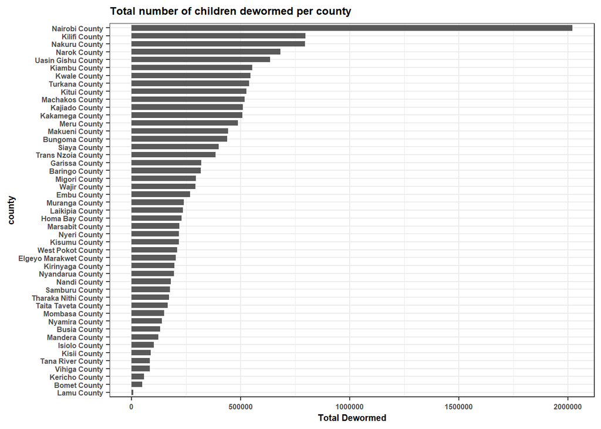

```r
library(dplyr)
library(ggplot2)
library(forcats)

cema_internship_task_2023 |>
  filter(!is.na(county)) |>
  group_by(county) |>
  summarize(`Total Dewormed` = sum(`Total Dewormed`, na.rm = T)) |>
  ggplot(aes(x = fct_reorder(county, `Total Dewormed`), y = `Total Dewormed`)) +
  geom_col(width = 0.7,position =  position_dodge(0.7))+
  theme_bw()+
  labs(x="county", y='Total Dewormed',
       title = "Total number of children dewormed per county")+
    theme(text=element_text(size=7.5, face ="bold"))+
  coord_flip()
```

Nairobi county has the highest number of children dewormed as shown above.

# What is the total number of children with acute malnutrition in each county arrange in descending order?

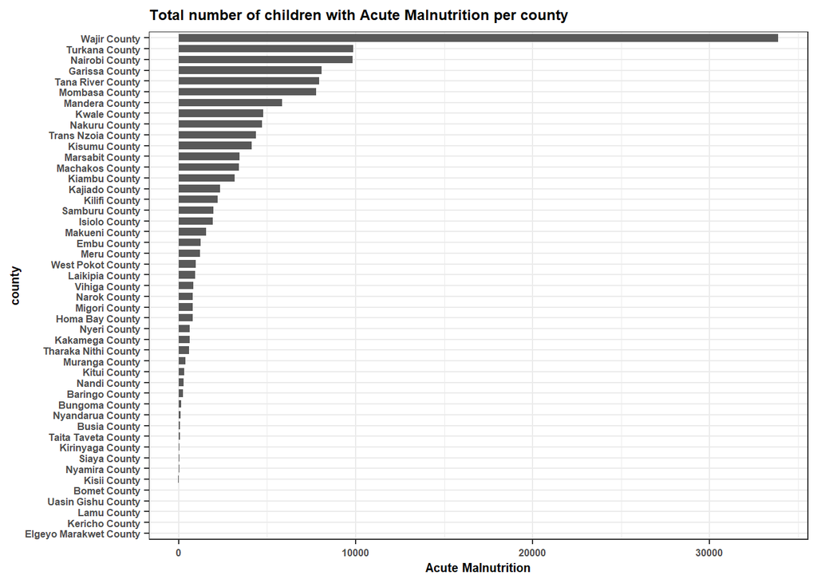

```r
cema_internship_task_2023 |>
  filter(!is.na(county)) |>
  group_by(county) |>
  summarize(`Acute Malnutrition` = sum(`Acute Malnutrition`, na.rm = T)) |>
  ggplot(aes(x = fct_reorder(county, `Acute Malnutrition`), y = `Acute Malnutrition`)) +
  geom_col(width = 0.7,position =  position_dodge(0.7))+
  theme_bw()+
  labs(x="county", y='Acute Malnutrition',
       title = "Total number of children with Acute Malnutrition per county")+
    theme(text=element_text(size=7.5, face ="bold"))+
  coord_flip()
```

From above, Wajir county has the highest number of children with Acute malnutrition.

# What is the total number of children with diarrhea cases in each county arranged in descending order?

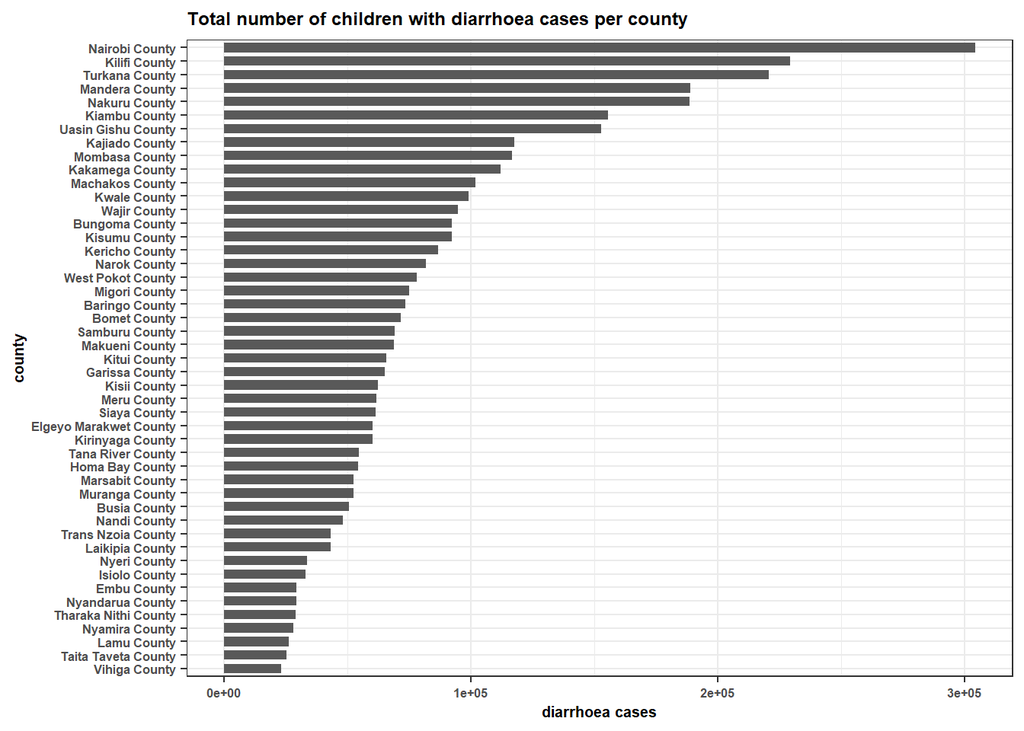

```r
cema_internship_task_2023 |>
  filter(!is.na(county)) |>
  group_by(county) |>
  summarize(`diarrhoea cases` = sum(`diarrhoea cases`, na.rm = T)) |>
  ggplot(aes(x = fct_reorder(county, `diarrhoea cases`), y = `diarrhoea cases`)) +
  geom_col(width = 0.7,position =  position_dodge(0.7))+
  theme_bw()+
  labs(x="county", y='diarrhoea cases',
       title = "Total number of children with diarrhoea cases per county")+
    theme(text=element_text(size=7.5, face ="bold"))+
  coord_flip()
```

From above, Nairobi is leading with the highest number of children with diarrhoea cases.

# Number of children <5 years who are underweight by age group.

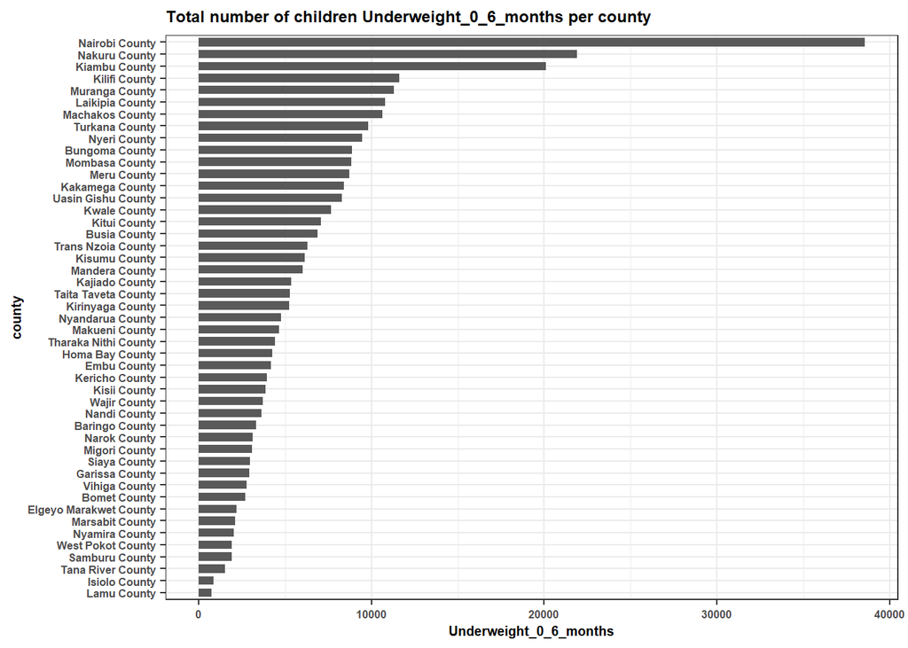

```r
underweight_over_time <- cema_internship_task_2023 %>%
 group_by(county) %>%
 summarize(
 Underweight_0_6_months=sum(`Underweight 0-<6 months`),
 Underweight_6_23_months=sum(`Underweight 6-23 months`),
 Underweight_24_59_months=sum(`Underweight 24-59 Months`)
)
 ggplot(data= underweight_over_time ,aes(x = fct_reorder(county, `Underweight_0_6_months`), y = `Underweight_0_6_months`)) +
  geom_col(width = 0.7,position =  position_dodge(0.7))+
  theme_bw()+
  labs(x="county", y='Underweight_0_6_months',
       title = "Total number of children Underweight_0_6_months per county")+
    theme(text=element_text(size=7.5, face ="bold"))+
  coord_flip()
```

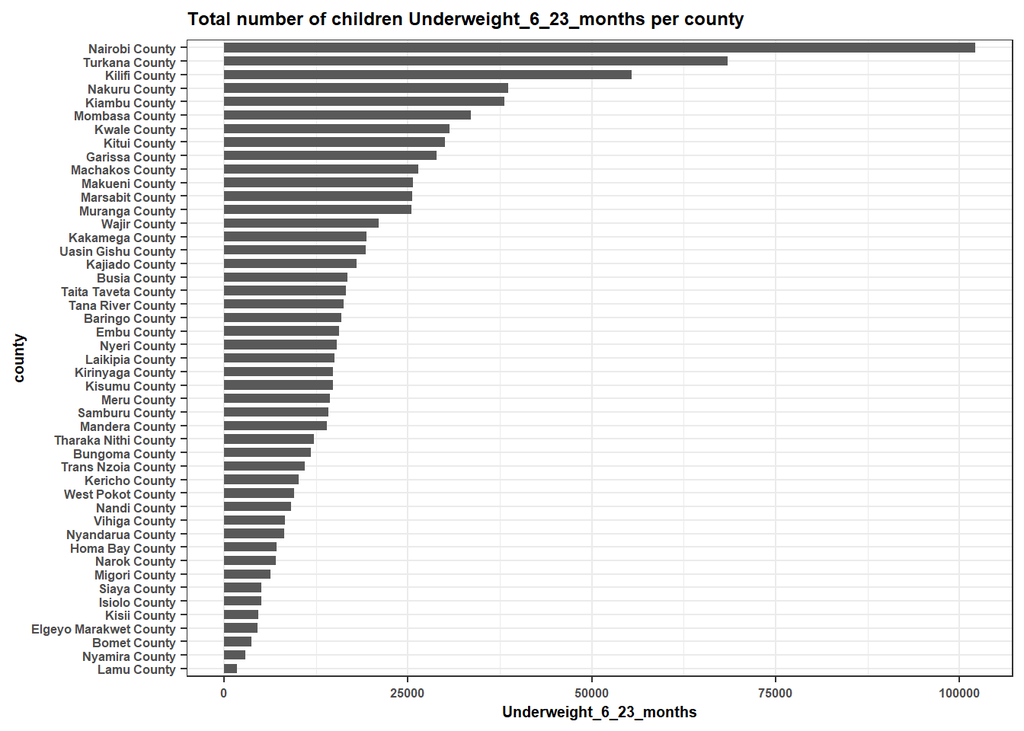

```r
  ggplot(data= underweight_over_time ,aes(x = fct_reorder(county, `Underweight_6_23_months`), y = `Underweight_6_23_months`)) +
  geom_col(width = 0.7,position =  position_dodge(0.7))+
  theme_bw()+
  labs(x="county", y='Underweight_6_23_months',
       title = "Total number of children Underweight_6_23_months per county")+
    theme(text=element_text(size=7.5, face ="bold"))+
  coord_flip()
```

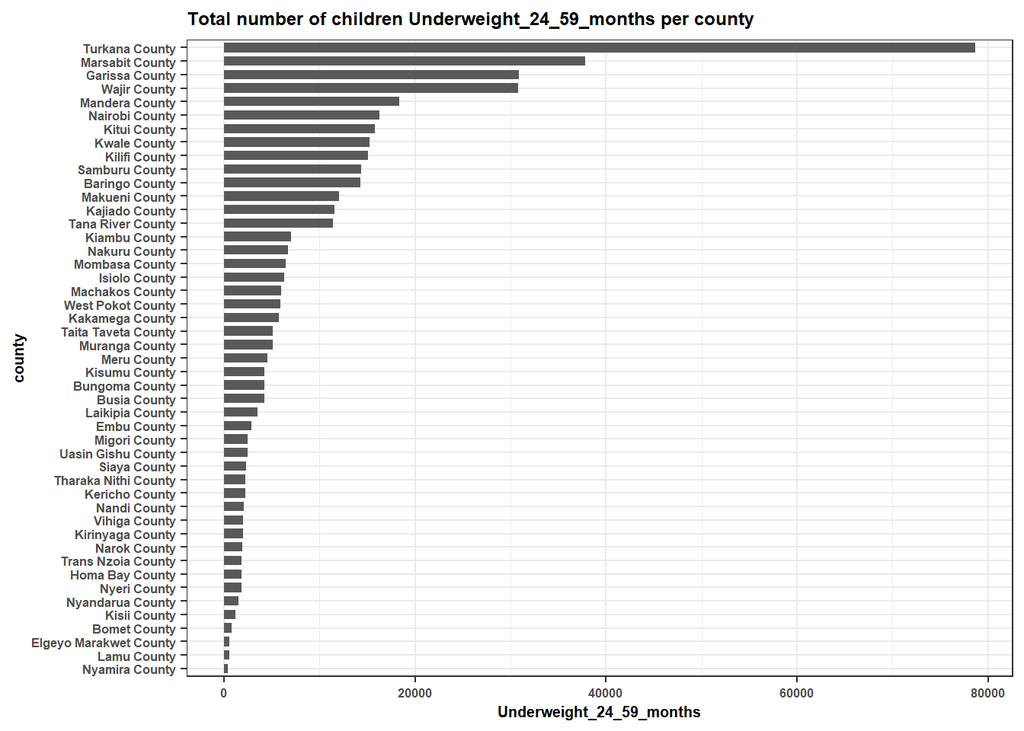

```r
 ggplot(data= underweight_over_time ,aes(x = fct_reorder(county, `Underweight_24_59_months`), y = `Underweight_24_59_months`)) +
  geom_col(width = 0.7,position =  position_dodge(0.7))+
  theme_bw()+
  labs(x="county", y='Underweight_24_59_months',
       title = "Total number of children Underweight_24_59_months per county")+
    theme(text=element_text(size=7.5, face ="bold"))+
  coord_flip()
```

```r
# Correlation analysis - Correlation between Total Dewormed and Acute Malnutrition
correlation <- cor(cema_internship_task_2023$`Total Dewormed`, cema_internship_task_2023$`Acute Malnutrition`, use = "pairwise.complete.obs")
print(paste("Correlation between Total Dewormed and Acute Malnutrition:", correlation))
```

```
## [1] "Correlation between Total Dewormed and Acute Malnutrition: 0.0937479743315865"
```

# Another research question:

How have the rates of diarrhea cases and underweight in children under 5 years evolved over the period from January 2021 to June 2023 across different counties in Kenya?

First convert period column to date format

```r
library(lubridate)
char_dates=cema_internship_task_2023$period
cema_internship_task_2023$period <- as.Date(paste0("01-", char_dates), format= "%d-%b-%y")

class(cema_internship_task_2023$period)
```

```
## [1] "Date"
```

```r
head(cema_internship_task_2023,3)
```

```
## # A tibble: 3 x 11
##   period     county  `Total Dewormed` `Acute Malnutrition` `stunted 6-23 months`
##   <date>     <chr>              <dbl>                <dbl>                 <dbl>
## 1 2023-01-01 Baring~             3659                    8                   471
## 2 2023-01-01 Bomet ~             1580                    0                     1
## 3 2023-01-01 Bungom~             6590                   24                    98
## # i 6 more variables: `stunted 0-<6 months` <dbl>,
## #   `stunted 24-59 months` <dbl>, `diarrhoea cases` <dbl>,
## #   `Underweight 0-<6 months` <dbl>, `Underweight 6-23 months` <dbl>,
## #   `Underweight 24-59 Months` <dbl>
```

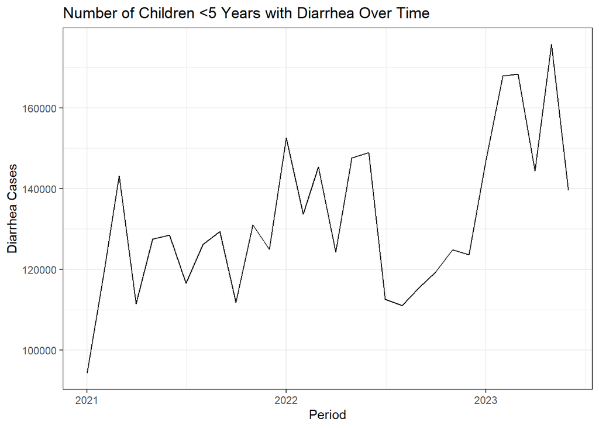

```r
# Group the data by Period and calculate the sum of Diarrhea cases for each month
diarrhea_over_time <- cema_internship_task_2023 %>%
  group_by(period) %>%
  summarize(Diarrhea_cases = sum(`diarrhoea cases`))

# Line plot of Diarrhea cases over time
ggplot(diarrhea_over_time, aes(x = period, y = Diarrhea_cases)) +
  geom_line() +
  theme_bw()+
  labs(x = "Period", y = "Diarrhea Cases", title = "Number of Children <5 Years with Diarrhea Over Time")
```

The graph above shows an uptrend, the number of children with diarrhoea cases has increased overtime.

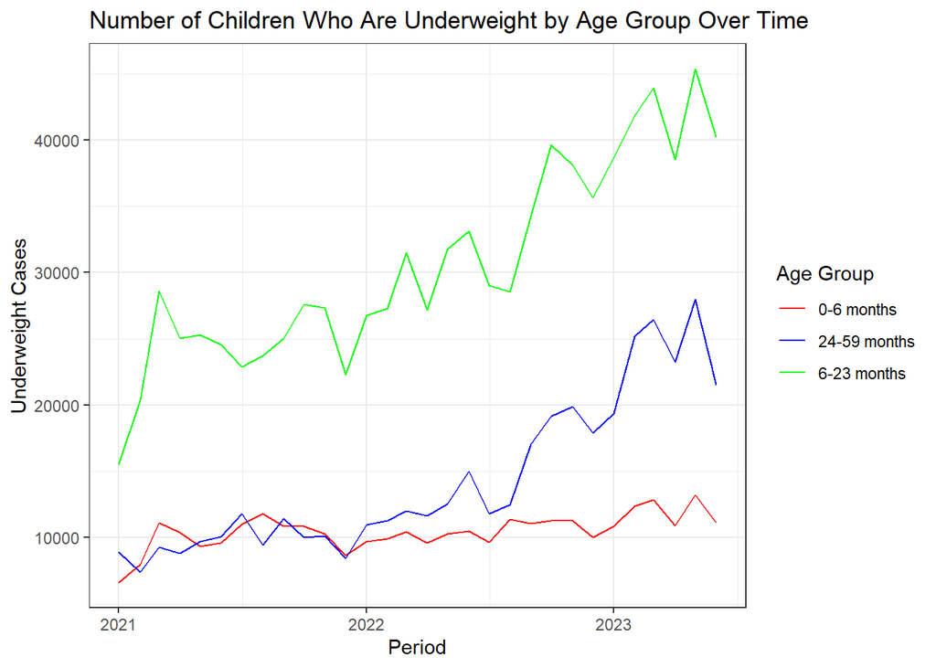

```r
# Group the data by Period and calculate the sum of Underweight cases for each age group and month
underweight_over_time <- cema_internship_task_2023 %>%
  group_by(period) %>%
  summarize(
    Underweight_0_6_months = sum(`Underweight 0-<6 months`),
    Underweight_6_23_months = sum(`Underweight 6-23 months`),
    Underweight_24_59_months = sum(`Underweight 24-59 Months`)
  )

# Line plot of Underweight cases by age group over time
ggplot(underweight_over_time, aes(x = period)) +
  geom_line(aes(y = Underweight_0_6_months, color = "0-6 months")) +
  geom_line(aes(y = Underweight_6_23_months, color = "6-23 months")) +
  geom_line(aes(y = Underweight_24_59_months, color = "24-59 months")) +
  theme_bw()+
  labs(x = "Period", y = "Underweight Cases", title = "Number of Children Who Are Underweight by Age Group Over Time") +
  scale_color_manual(values = c("red", "blue", "green"), name = "Age Group")
```

From the graph above, children between the age of 6-23 months have recorded the highest number of underweight children among the other age groups, and has gradually increased over time.Children between 0-6 have less underweight cases.